# Linear models and ANOVA

Nicolas Legrand (legrand@cyceron.fr)

# Basic Statistics

## t Tests

### One sample

```r
t.test(iris$Sepal.Length)
```

```
##
##  One Sample t-test
##
## data:  iris$Sepal.Length
## t = 86.425, df = 149, p-value < 2.2e-16
## alternative hypothesis: true mean is not equal to 0
## 95 percent confidence interval:
##  5.709732 5.976934
## sample estimates:
## mean of x
##  5.843333
```

### Two sample

```r
t.test(iris$Sepal.Length, iris$Petal.Length)
```

```
##
##  Welch Two Sample t-test
##
## data:  iris$Sepal.Length and iris$Petal.Length
## t = 13.098, df = 211.54, p-value < 2.2e-16
## alternative hypothesis: true difference in means is not equal to 0
## 95 percent confidence interval:
##  1.771500 2.399166
## sample estimates:
## mean of x mean of y
##  5.843333  3.758000
```

### Paired

```r
t.test(iris$Sepal.Length, iris$Petal.Length, paired = T)
```

```
##
##  Paired t-test
##
## data:  iris$Sepal.Length and iris$Petal.Length
## t = 22.813, df = 149, p-value < 2.2e-16
## alternative hypothesis: true difference in means is not equal to 0
## 95 percent confidence interval:
##  1.904708 2.265959
## sample estimates:
## mean of the differences
##                2.085333
```

### One-tailed

```r
t.test(iris$Sepal.Length, alternative = "greater")
```

```
##
##  One Sample t-test
##
## data:  iris$Sepal.Length
## t = 86.425, df = 149, p-value < 2.2e-16
## alternative hypothesis: true mean is greater than 0
## 95 percent confidence interval:
##  5.731427      Inf
## sample estimates:
## mean of x
##  5.843333
```

## Correlation

### Coefficient

```r
cor(iris$Sepal.Length, iris$Petal.Length,
    method = "pearson") # "spearman" "kendall"
```

```
## [1] 0.8717538
```

### Significance

```r
cor.test(iris$Sepal.Length, iris$Petal.Length,
         method = "kendall") # "spearman" + (exact = F) "pearson"
```

```
##
##  Kendall's rank correlation tau
##
## data:  iris$Sepal.Length and iris$Petal.Length
## z = 12.647, p-value < 2.2e-16
## alternative hypothesis: true tau is not equal to 0
## sample estimates:
##       tau
## 0.7185159
```

# Linear regression

```r
attach(iris)
```

Data are loaded in workspace so you don’t need to specify e.g. “iris$Sepal.Length” but “Sepal.Length”

## Fit Linear Model

Formula : Y ~ X => Y is modeled as X

Sources : http://data.princeton.edu/R/linearModels.html

[video not shown]

```r
mod = lm(Petal.Length ~ Sepal.Length)
```

## Examining the model

```r
summary(mod)
```

```
##
## Call:
## lm(formula = Petal.Length ~ Sepal.Length)
##
## Residuals:
##      Min       1Q   Median       3Q      Max
## -2.47747 -0.59072 -0.00668  0.60484  2.49512
##
## Coefficients:
##              Estimate Std. Error t value Pr(>|t|)
## (Intercept)  -7.10144    0.50666  -14.02   <2e-16 ***
## Sepal.Length  1.85843    0.08586   21.65   <2e-16 ***
## ---
## Signif. codes:  0 '***' 0.001 '**' 0.01 '*' 0.05 '.' 0.1 ' ' 1
##
## Residual standard error: 0.8678 on 148 degrees of freedom
## Multiple R-squared:   0.76,  Adjusted R-squared:  0.7583
## F-statistic: 468.6 on 1 and 148 DF,  p-value: < 2.2e-16
```

List data contained in the model

```r
attributes(mod)
```

```
## $names
##  [1] "coefficients"  "residuals"     "effects"       "rank"
##  [5] "fitted.values" "assign"        "qr"            "df.residual"
##  [9] "xlevels"       "call"          "terms"         "model"
##
## $class
## [1] "lm"
```

Confidence interval (95%)

```r
confint(mod, level = 0.95)
```

```
##                  2.5 %    97.5 %
## (Intercept)  -8.102670 -6.100217
## Sepal.Length  1.688772  2.028094
```

Hierarchical anova table for the analysis of covariance

```r
anova(mod)
```

```
## Analysis of Variance Table
##
## Response: Petal.Length
##               Df Sum Sq Mean Sq F value    Pr(>F)
## Sepal.Length   1 352.87  352.87  468.55 < 2.2e-16 ***
## Residuals    148 111.46    0.75
## ---
## Signif. codes:  0 '***' 0.001 '**' 0.01 '*' 0.05 '.' 0.1 ' ' 1
```

## Plot

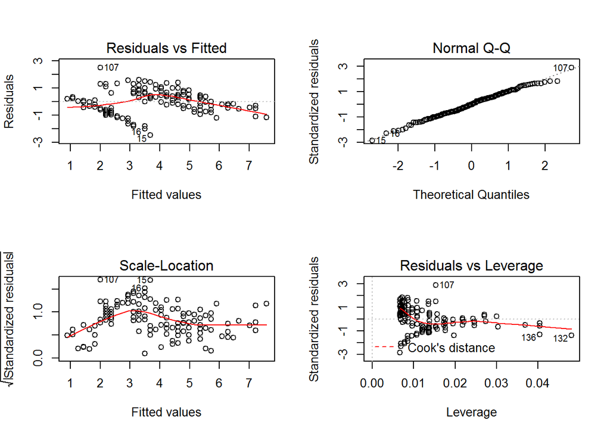

```r
par(mfrow=c(2,2)) # Plot in a layout with 2 rows and 2 columns
plot(mod)
```

```r
par(mfrow=c(1,1)) # Go back to a single graph per window
```

Four plots: residuals versus fitted values, a Q-Q plot of standardized residuals, a scale-location plot (square roots of standardized residuals versus fitted values, and a plot of residuals versus leverage that adds bands corresponding to Cook’s distances of 0.5 and 1

## Plot

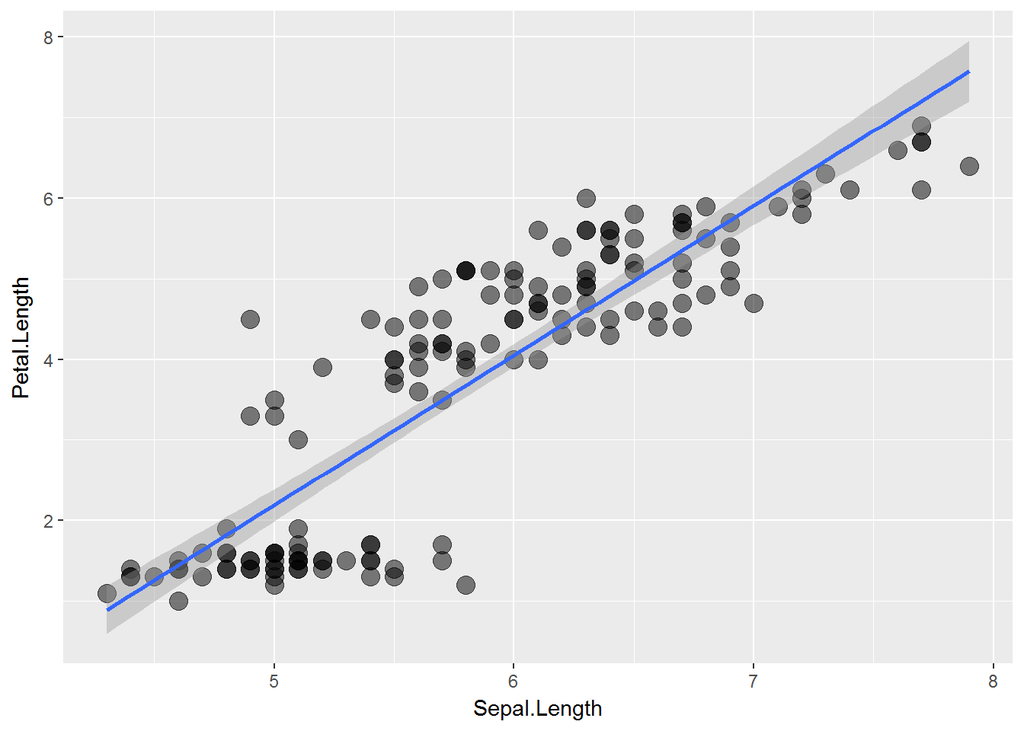

```r
library(ggplot2)
ggplot(data = iris, aes(x= Sepal.Length, y = Petal.Length))+
  geom_point(size = 4,
             alpha = 0.5)+
  geom_smooth(method = "lm")
```

# Multile regression

Wilkinson notation:

- **to combine elementary terms, as in A+B**

  for interactions, as in A:B;
- for both main effects and interactions, so A*B = A+B+A:B

```r
mod2 = lm(Sepal.Length ~ Petal.Length + Petal.Width)
anova(mod2)
```

```
## Analysis of Variance Table
##
## Response: Sepal.Length
##               Df Sum Sq Mean Sq  F value  Pr(>F)
## Petal.Length   1 77.643  77.643 477.9411 < 2e-16 ***
## Petal.Width    1  0.644   0.644   3.9663 0.04827 *
## Residuals    147 23.881   0.162
## ---
## Signif. codes:  0 '***' 0.001 '**' 0.01 '*' 0.05 '.' 0.1 ' ' 1
```

See [here](http://data.princeton.edu/R/glms.html) for GLM

```r
detach(iris)
```

Drop iris dataset when you’re done.

# ANOVA

```r
library(ez)
```

- Load the data

```r
data(ANT)
library(knitr)
kable(head(ANT)) # Use kable() for nicer output for tables
```

| subnum | group | block | trial | cue | flank | location | direction | rt | error |
| --- | --- | --- | --- | --- | --- | --- | --- | --- | --- |
| 1 | Treatment | 1 | 1 | None | Neutral | up | left | 398.6773 | 0 |
| 1 | Treatment | 1 | 2 | Center | Neutral | up | left | 389.1822 | 0 |
| 1 | Treatment | 1 | 3 | Double | Neutral | up | left | 333.2186 | 0 |
| 1 | Treatment | 1 | 4 | Spatial | Neutral | up | left | 419.7640 | 0 |
| 1 | Treatment | 1 | 5 | None | Congruent | up | left | 446.4754 | 0 |
| 1 | Treatment | 1 | 6 | Center | Congruent | up | left | 338.9766 | 0 |

- Check structure of data

```r
str(ANT)
```

```
## 'data.frame':    5760 obs. of  10 variables:
##  $ subnum   : Factor w/ 20 levels "1","2","3","4",..: 1 1 1 1 1 1 1 1 1 1 ...
##  $ group    : Factor w/ 2 levels "Control","Treatment": 2 2 2 2 2 2 2 2 2 2 ...
##  $ block    : int  1 1 1 1 1 1 1 1 1 1 ...
##  $ trial    : int  1 2 3 4 5 6 7 8 9 10 ...
##  $ cue      : Factor w/ 4 levels "None","Center",..: 1 2 3 4 1 2 3 4 1 2 ...
##  $ flank    : Factor w/ 3 levels "Neutral","Congruent",..: 1 1 1 1 2 2 2 2 3 3 ...
##  $ location : Factor w/ 2 levels "down","up": 2 2 2 2 2 2 2 2 2 2 ...
##  $ direction: Factor w/ 2 levels "left","right": 1 1 1 1 1 1 1 1 1 1 ...
##  $ rt       : num  399 389 333 420 446 ...
##  $ error    : num  0 0 0 0 0 0 0 0 0 0 ...
```

- Check balance of between subjects factors

Group

```r
table(ANT$group)
```

```
##
##   Control Treatment
##      2880      2880
```

Cue

```r
table(ANT$cue)
```

```
##
##    None  Center  Double Spatial
##    1440    1440    1440    1440
```

Flank

```r
table(ANT$flank)
```

```
##
##     Neutral   Congruent Incongruent
##        1920        1920        1920
```

Group + Cue + Flank

```r
table(ANT$cue, ANT$flank, ANT$group)
```

```
## , ,  = Control
##
##
##           Neutral Congruent Incongruent
##   None        240       240         240
##   Center      240       240         240
##   Double      240       240         240
##   Spatial     240       240         240
##
## , ,  = Treatment
##
##
##           Neutral Congruent Incongruent
##   None        240       240         240
##   Center      240       240         240
##   Double      240       240         240
##   Spatial     240       240         240
```

The design is balanced

- **afex package** : function *aov_ez()*

```r
library(afex)
```

See documentation [here](https://www.r-bloggers.com/anova-in-r-afex-may-be-the-solution-you-are-looking-for/) and here

## One-way ANOVA

```r
PlantGrowth$Subject = 1:dim(PlantGrowth)[1] # Create a new column encoding subject number
mod = aov_ez(data = PlantGrowth,
             id = "Subject",        # Culumn where subject ID is encoded
             between = "group",     # Within-subejct variable (repeated measures)
             dv = "weight")         # Dependent variable
```

```
## Contrasts set to contr.sum for the following variables: group
```

```r
knitr::kable(nice(mod))
```

| Effect | df | MSE | F | ges | p.value |
| --- | --- | --- | --- | --- | --- |
| group | 2, 27 | 0.39 | 4.85 * | .26 | .02 |

- Investigate the marginal means

‘afex_aov’ objects (here “mod) can be passed to ‘lsmeans’ for contrasts and follow-up tests.

```r
ls = lsmeans(mod, "group")
```

- Post-hoc

Tuckey

```r
contrast(ls, method = "pairwise")
```

```
##  contrast    estimate        SE df t.ratio p.value
##  ctrl - trt1    0.371 0.2787816 27   1.331  0.3909
##  ctrl - trt2   -0.494 0.2787816 27  -1.772  0.1980
##  trt1 - trt2   -0.865 0.2787816 27  -3.103  0.0120
##
## P value adjustment: tukey method for comparing a family of 3 estimates
```

Bonferroni

```r
contrast(ls, method="pairwise", adjust="bonferroni")
```

```
##  contrast    estimate        SE df t.ratio p.value
##  ctrl - trt1    0.371 0.2787816 27   1.331  0.5832
##  ctrl - trt2   -0.494 0.2787816 27  -1.772  0.2630
##  trt1 - trt2   -0.865 0.2787816 27  -3.103  0.0134
##
## P value adjustment: bonferroni method for 3 tests
```

- Plot results

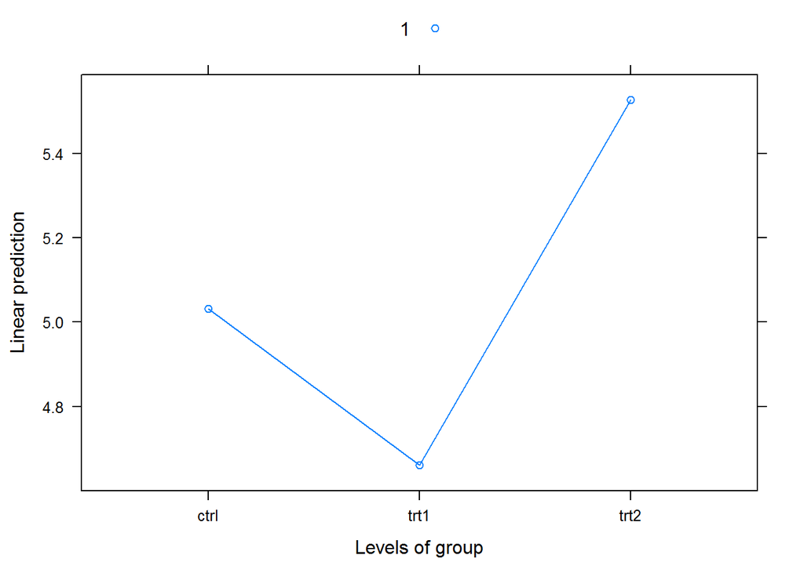

```r
lsmip(mod, ~ group)
```

## Two-way ANOVA

```r
data(obk.long, package = "afex")

mod2 = aov_ez("id",
              "value",
              obk.long,
              between = c("treatment", "gender"),
              observed = "gender")
```

```
## Contrasts set to contr.sum for the following variables: treatment, gender
```

- “observed” indicates which of the variables are observed (i.e, measured) as compared to experimentally manipulated. The default effect size reported (generalized eta-squared) requires correct specification of the observed (in contrast to manipulated) variables.
- Plot

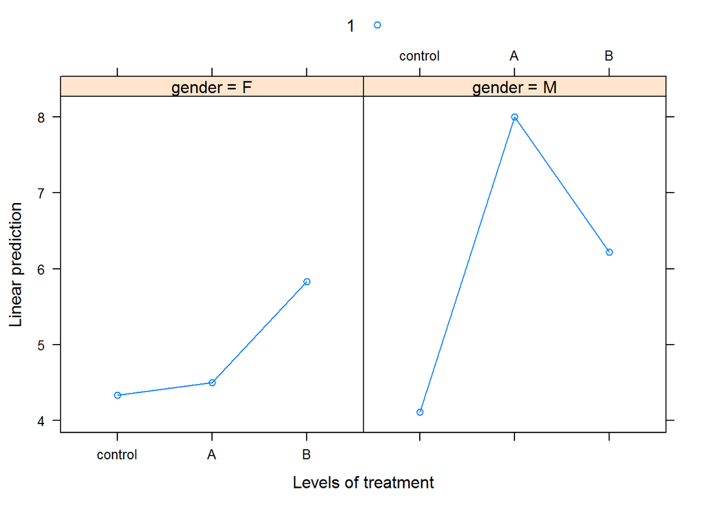

```r
lsmip(mod2, ~ treatment | gender)
```

## Repeated measures ANOVA

```r
mod = aov_ez(data = ANT,
       id = "subnum",     # Culumn where subject ID is encoded
       within = "cue",    # Within-subejct variable (repeated measures)
       dv = "rt")
knitr::kable(nice(mod))
```

| Effect | df | MSE | F | ges | p.value |
| --- | --- | --- | --- | --- | --- |
| cue | 2.71, 51.40 | 52.44 | 540.86 *** | .95 | <.0001 |

- Post-hoc

```r
posthoc = lsmeans(mod, ~ cue)
```

```r
contrast(posthoc, method="pairwise")
```

```
##  contrast          estimate      SE df t.ratio p.value
##  None - Center    41.948201 2.17442 57  19.292  <.0001
##  None - Double    48.408656 2.17442 57  22.263  <.0001
##  None - Spatial   87.323670 2.17442 57  40.160  <.0001
##  Center - Double   6.460455 2.17442 57   2.971  0.0219
##  Center - Spatial 45.375469 2.17442 57  20.868  <.0001
##  Double - Spatial 38.915014 2.17442 57  17.897  <.0001
##
## P value adjustment: tukey method for comparing a family of 4 estimates
```

- Plot

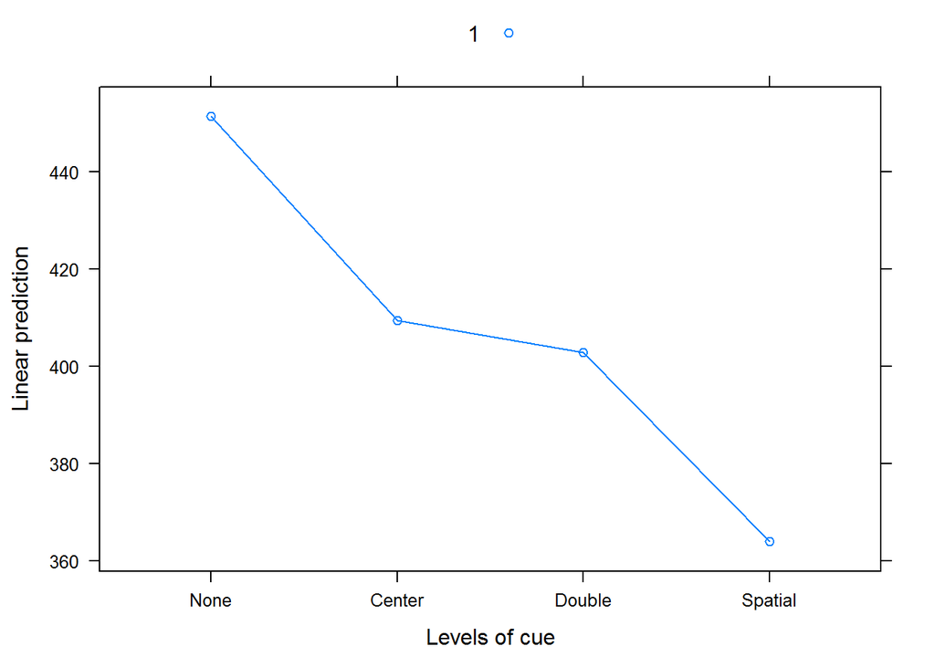

```r
lsmip(mod, ~ cue)
```

## Mixed design

One within subjects factor and one between subjects factor.

```r
mod2 = aov_ez(data = ANT,
              id = "subnum",
              within = "cue",
              between = "group",
              dv = "rt")
summary(mod2)
```

```
##
## Univariate Type III Repeated-Measures ANOVA Assuming Sphericity
##
##                   SS num Df Error SS den Df          F    Pr(>F)
## (Intercept) 13246206      1    624.5     18 3.8180e+05 < 2.2e-16 ***
## group            563      1    624.5     18 1.6223e+01 0.0007894 ***
## cue            76718      3   2244.9     54 6.1514e+02 < 2.2e-16 ***
## group:cue        450      3   2244.9     54 3.6094e+00 0.0189248 *
## ---
## Signif. codes:  0 '***' 0.001 '**' 0.01 '*' 0.05 '.' 0.1 ' ' 1
##
##
## Mauchly Tests for Sphericity
##
##           Test statistic p-value
## cue              0.73138 0.38906
## group:cue        0.73138 0.38906
##
##
## Greenhouse-Geisser and Huynh-Feldt Corrections
##  for Departure from Sphericity
##
##            GG eps Pr(>F[GG])
## cue       0.82857    < 2e-16 ***
## group:cue 0.82857    0.02677 *
## ---
## Signif. codes:  0 '***' 0.001 '**' 0.01 '*' 0.05 '.' 0.1 ' ' 1
##
##              HF eps   Pr(>F[HF])
## cue       0.9717613 1.357594e-40
## group:cue 0.9717613 2.003235e-02
```

- Plot

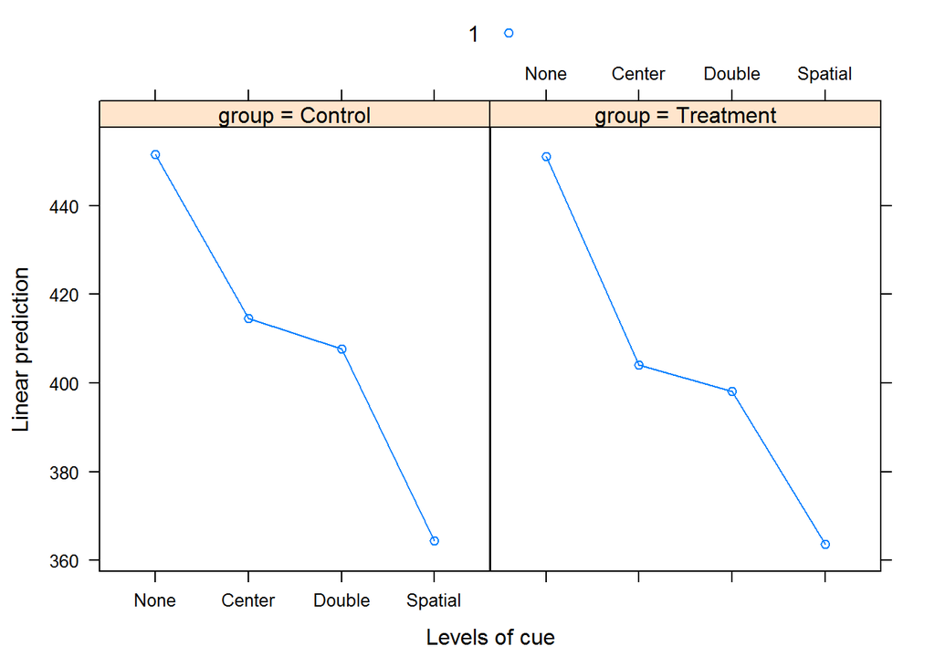

```r
lsmip(mod2, ~ cue | group)
```

- Post-hoc Test all pairwise comparisons within each level of **group**

```r
ls=lsmeans(mod2, ~ cue|group)
```

```r
contrast(ls, method="pairwise")
```

```
## group = Control:
##  contrast          estimate       SE df t.ratio p.value
##  None - Center    36.933006 2.883459 54  12.809  <.0001
##  None - Double    43.818897 2.883459 54  15.197  <.0001
##  None - Spatial   87.186023 2.883459 54  30.237  <.0001
##  Center - Double   6.885891 2.883459 54   2.388  0.0916
##  Center - Spatial 50.253017 2.883459 54  17.428  <.0001
##  Double - Spatial 43.367126 2.883459 54  15.040  <.0001
##
## group = Treatment:
##  contrast          estimate       SE df t.ratio p.value
##  None - Center    46.963396 2.883459 54  16.287  <.0001
##  None - Double    52.998415 2.883459 54  18.380  <.0001
##  None - Spatial   87.461317 2.883459 54  30.332  <.0001
##  Center - Double   6.035019 2.883459 54   2.093  0.1684
##  Center - Spatial 40.497920 2.883459 54  14.045  <.0001
##  Double - Spatial 34.462902 2.883459 54  11.952  <.0001
##
## P value adjustment: tukey method for comparing a family of 4 estimates
```